# Marcado y trazado

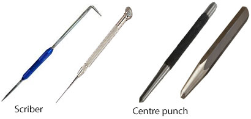

## Concepto

El trazado o marcado consiste en indicar sobre una pieza de metal dónde se realizarán operaciones como cortes, pliegues o perforaciones. Se puede distinguir entre dos acciones:

- **Marcar:** hacer puntos de referencia sobre el metal, por ejemplo, para ubicar el centro de un taladro o los vértices de un contorno. Estos puntos sirven como guía precisa para herramientas como brocas o compases.
- **Trazar:** dibujar líneas guía sobre la superficie del metal que indiquen bordes de corte, pliegues, etc.

## Puntas de marcar (Punches)

Las puntas de marcar son herramientas manuales en forma de punzón, utilizadas para crear pequeñas hendiduras en la superficie de una pieza metálica. Suelen fabricarse con **acero al carbono templado** para uso general o con **carburo de tungsteno** para trabajar sobre materiales muy duros, ya que este ofrece mayor resistencia al desgaste.

Hay de varios tipos, en la figura se muestran dos que son comunes:

- **a) De punta fina (dot punch):** Se emplea para realizar pequeñas hendiduras que sirven como referencia por ejemplo para ubicar la punta de un compás. Se golpea suavemente con un martillo para no dañar en exceso la superficie.
- **b) De punta más gruesa (centre punch):** Se utiliza para generar hendiduras más profundas que actúan como guía para la punta de una mecha antes de perforar. Requiere un golpe más firme que el dot punch.

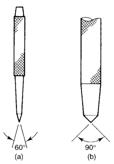

Fuente: Timings (2008).

**versión en inglés**

Marking points are hand tools shaped like punches, used to create small indentations on the surface of a metal workpiece. They are usually made of **hardened carbon steel** for general use or **tungsten carbide** for working on very hard materials, as it offers greater wear resistance.

There are several types; the figure shows two common ones:

- **a) Dot punch:** Used to make small indentations that serve as reference points, for example, to position the tip of a compass. It is struck lightly with a hammer to avoid excessive damage to the surface.
- **b) Centre punch:** Used to create deeper indentations that act as a guide for the tip of a drill bit before drilling. It requires a firmer blow than the dot punch.

## Uso recomendado

Para evitar errores se recomienda usarlo como se muestra en la figura:

- **a)** Ubicar la punta de marcar inclinada para ver mejor
- **b)** Enderezar y dar un golpe ligero o firme dependiendo el trabajo a realizar. Además siempre puedes dar golpes adicionales si quieres agrandar la marca.

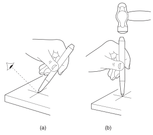

Fuente: Timings (2008).

## Herramientas para trazar

Existen diversas herramientas e instrumentos diseñados para trazar líneas sobre superficies metálicas, cada uno adecuado según la precisión requerida y el tipo de trabajo.

### Punta de trazar (Scriber)

La herramienta tradicional es la punta de trazar o scriber, que raya el metal dejando un trazo muy fino y preciso. Este trazo es indeleble (no se borra fácilmente), pero puede resultar poco visible, por lo que suele mejorarse recubriendo la superficie con una fina capa de tiza, tinta o pintura antes de marcar.

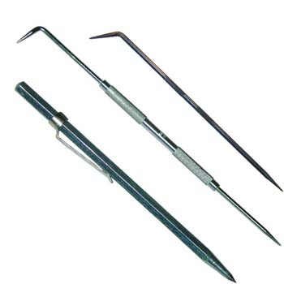

Fuente: industrial.ferreteriapuig.com

### Otros instrumentos de trazar

De manera más sencilla, se pueden usar lápices comunes o marcadores de fibra para realizar líneas temporales en metales, especialmente cuando no se desea dañar la superficie.

También existen lápices para soldador, similares a los lápices tradicionales, pero que dejan un trazo en colores más visibles.

[figure not shown]

Fuente: ferreteriaelrosarino.com.ar

## Algunos ejemplos prácticos de uso

En este sección hay algunos ejemplos con elementos fáciles de encontrar en el taller:

- [Aquí](https://www.youtubetrimmer.com/view/?v=g37Tc797bag&start=4&end=53&loop=0) puedes ver un modo sencillo de marcar usando una punta de trazar y tiza mojada.
- [Aquí](https://www.youtubetrimmer.com/view/?v=C-DKXmuFh6Q&start=131&end=163&loop=0) puedes ver como se puede usar el calibre para marcar. Lo recomendable es que la pieza tenga algún tipo de recubrimiento (tiza, tinta, pintura) para que el trazo se vea mejor.
- [Aquí](https://www.youtubetrimmer.com/view/?v=cjtjteqcIII&start=88&end=129&loop=0) puedes ver un modo de usar una punta de trazar sobre tinta.

**Algunas fuentes usadas**

- Timings, R. (2008). Fabrication and Welding Engineering. Elsevier.
- Diversos videos seleccionados de Youtube